# Simple Linear Regression

Institut für Organisation und Globale Managementstudien, JKU Linz

**Regression models are the workhorses of data science.**

**They are the most well described, practical and theoretically understood models in statistics.**

**A data scientist well versed in regression models will be able to solve an incredible array of problems.**

Brian Caffo, 2015

## Definition, Terminology

In statistics, **linear regression** is an approach for  
modeling the relationship between a  
scalar dependent variable (predicted outcome) and  
one or more explanatory variables (predictor) denoted X.

1. **Simple linear regression**: one explanatory variable
2. **Multivariable linear regression**: more than one explanatory variables
3. **Multivariate linear regression**: prediction of multiple correlated dependent variables (not covered in this class).

[See Wikipedea](https://en.wikipedia.org/wiki/Linear_regression)

## Basic Example: Diamond Data

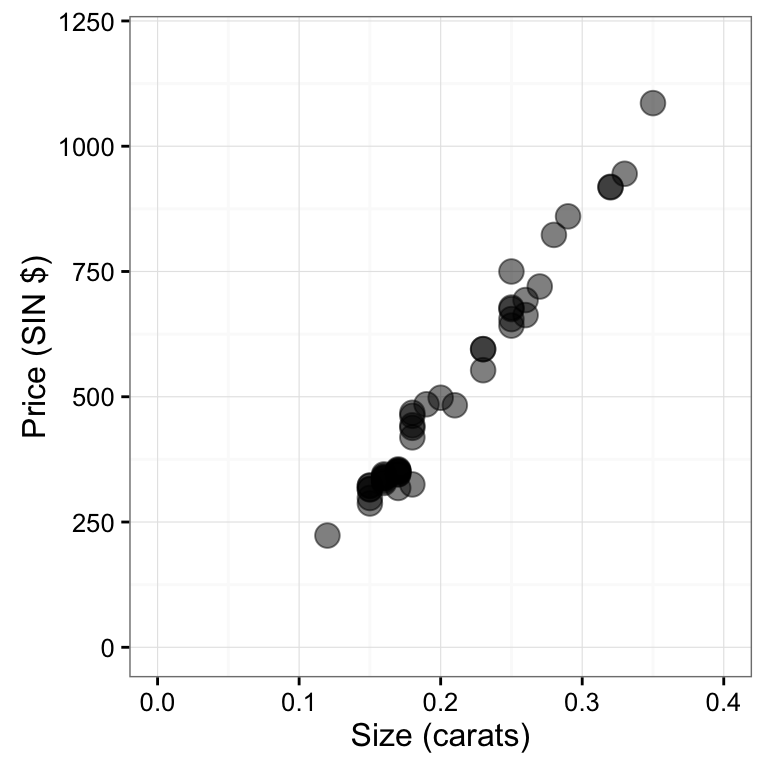

Use `data("diamond")` from `library(UsingR)`

## Straight Line with Best Fit

\(Y = \beta_0 + \beta_1 X + \epsilon_i\)

\(\beta_0\) … Intercept at \(X=0\)  
\(\beta_1\) … Slope  
\(\epsilon_i\) … Error \(\sim N(0, \sigma^2)\)

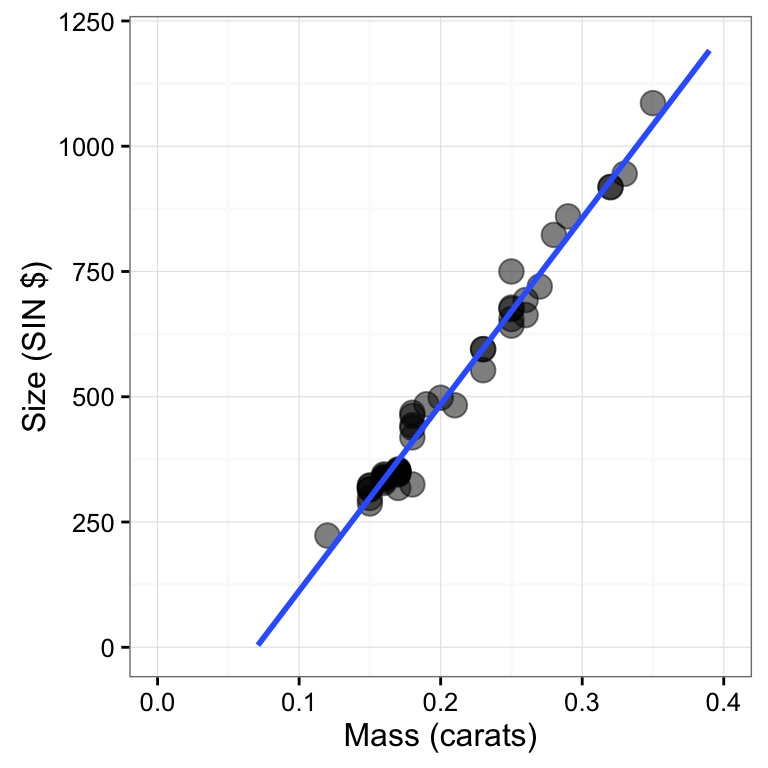

## Estimating Regression Coefficients

## Best Fit: Least Square Estimate

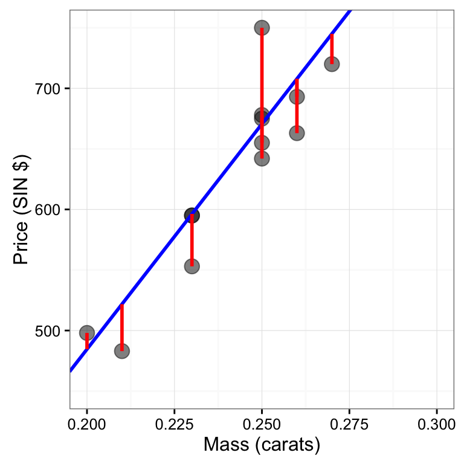

\[ \text{Find min for} \sum_{i=1}^n(Y_i - \beta_0 - \beta_1 X_i)^2 \]

## Least Square Estimates

\[ \hat \beta_1 = \frac{\sum_{n=1}^n (x_i - \bar x)(y_i-\bar y)}{\sum_{n=1}^n (x_i-\bar x)^2} \]

\[ \hat\beta_0 = \bar y - \hat \beta_1 \bar x \]

Alternative:

\[\hat \beta_1 = Cor(Y, X) \frac{Sd(Y)}{Sd(X)}\]

\[r_{xy} = \frac{\sum_{i=1}^n (x_i - \bar x)(y_i - \bar y)}{(n-1) s_x s_y} \]

## Least Square Estimate in R

```r
x <- diamond$carat; y <- diamond$price
beta1hat <- sum((x - mean(x)) * ((y - mean(y)))) /
    sum((x - mean(x))^2)

beta0hat <- mean(y) - beta1hat * mean(x)

beta0hat; beta1hat
```

```
## [1] -259.6259
```

```
## [1] 3721.025
```

```r
cor(x, y) * sd(y) / sd(x)
```

```
## [1] 3721.025
```

## Linear Regression Model in R

```r
fit <- lm(price ~ carat, data = diamond)
fit
```

```
##
## Call:
## lm(formula = price ~ carat, data = diamond)
##
## Coefficients:
## (Intercept)        carat
##      -259.6       3721.0
```

**Intercept:** The price of a 0 carart diamond is SIN$-259.6?!

**Slope:** For an increase in mass of 1 carat the price for a diamondincreases SIN$ 3721.

## Centering

By substracting the mean from the variable carat we are getting a more interpretable intercept. This process is called **centering**.

```r
fitCentered <- lm(price ~ I(carat - mean(carat)), diamond)
fitCentered$coef
```

```
##            (Intercept) I(carat - mean(carat))
##               500.0833              3721.0249
```

**The expected price for an average sized diamond of 0.204 carat is SIN$ 500.1.**

## Scaling

1 carat increase in a diamond is pretty large.  
How about 1/10th of a carat?

```r
fitScaled <- lm(price ~ I(carat * 10), diamond)
fitScaled$coef
```

```
##   (Intercept) I(carat * 10)
##     -259.6259      372.1025
```

**The expected price increase for a diamondis SIN$ 372.1 per 0.1 carat.**

## Prediction

## Prediction of new values

Let's predict the prices of diamonds with 0.16, 0.27 and 0.34 carat.

```r
newd <- c(0.16, 0.27, 0.34)
coef(fit)[1] + coef(fit)[2] * newd
```

```
## [1]  335.7381  745.0508 1005.5225
```

```r
predict(fit, newdata = data.frame(carat = newd))
```

```
##         1         2         3
##  335.7381  745.0508 1005.5225
```

## Residuals, Variability

## Linear Model

\(\text{price} = -259.6 + 3721 \times \text{carat} + \epsilon\)

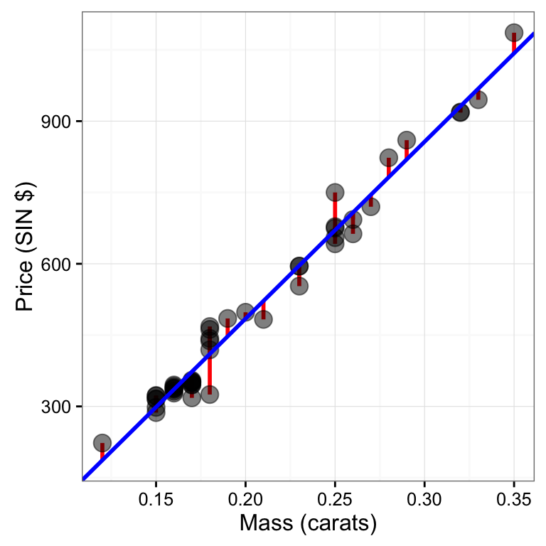

## Residuals

Ploting only the residuals (estimand for \(\epsilon\)):

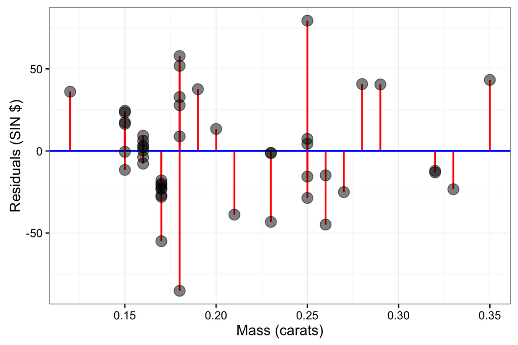

## Properties of the Residuals

- Residuals are useful for investigating poor model fit.
- Residuals can be thought of as the outcome (\(Y\)) with thelinear association of the predictor (\(X\)) removed.
- One differentiates **residual variation** (variation after removingthe predictor) from **systematic variation** (variation explained by the regression model).
- \(E[e_i] = 0\).
- If an intercept is included, \(\sum_{i=1}^n e_i = 0\).
- If a regressor variable, \(X_i\), is included in the model \(\sum_{i=1}^n e_i X_i = 0\).

## Residuals

- Model \(Y_i = \beta_0 + \beta_1 X_i + \epsilon_i\) where \(\epsilon_i \sim N(0, \sigma^2)\).
- Observed outcome \(i\) is \(Y_i\) at predictor value \(X_i\)
- Predicted outcome \(i\) is \(\hat Y_i\) at predictor value \(X_i\) is\[ \hat Y_i = \hat \beta_0 + \hat \beta_1 X_i \]
- A residual is the line between the observed and predicted outcome\[ e_i = Y_i - \hat Y_i \]
- Least squares minimizes \(\sum_{i=1}^n e_i^2\)
- The \(e_i\) can be thought of as estimates of the \(\epsilon_i\).

## Example: Non-linear Data

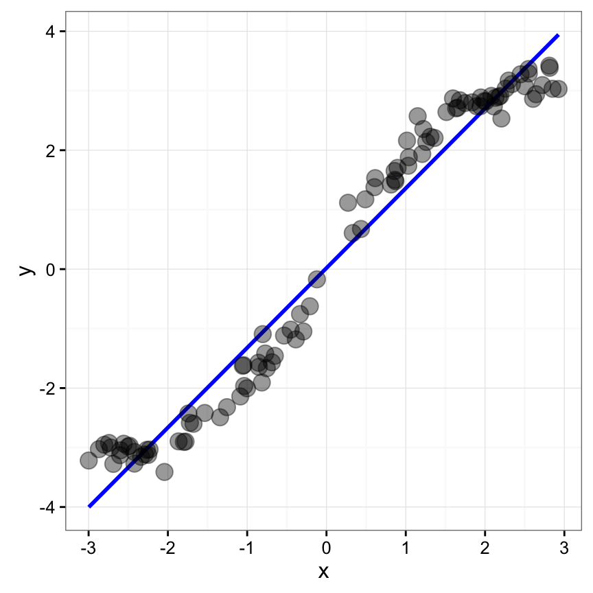

## Residual Plot of Non-Linear Data

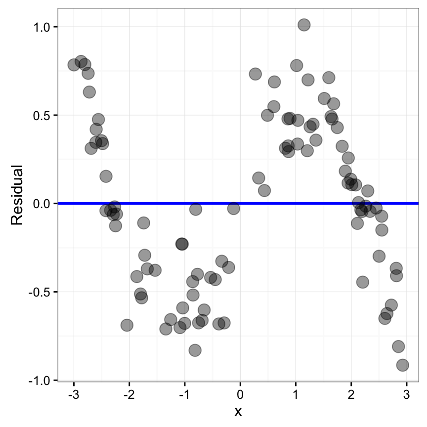

## Summarizing Variation

- The total variability in our response is the variability around an intercept\(\sum_{i=1}^n (Y_i - \bar Y)^2\)
- The regression variability is the variability that is explained by adding thepredictor \(\sum_{i=1}^n (\hat Y_i - \bar Y)^2\)
- The error variability is what's leftover around the regression line\(\sum_{i=1}^n (Y_i - \hat Y_i)^2\)
- Neat fact\[ \sum_{i=1}^n (Y_i - \bar Y)^2 = \sum_{i=1}^n (\hat Y_i - \bar Y)^2 + \sum_{i=1}^n (Y_i - \hat Y_i)^2 \]

## R Squared

- R squared is the percentage of the total variability that is explainedby the linear relationship with the predictor.\[ R^2 = \frac{\sum_{i=1}^n (\hat Y_i - \bar Y)^2}{\sum_{i=1}^n (Y_i - \bar Y)^2} \]

```r
summary(fit)$r.squared
```

```
## [1] 0.9782608
```

- The predictor size (in carat) explains 97.8%of the variability in diamond prices.
- \(R^2\) is the sample correlation squared.

## Diamond Example

```r
y <- diamond$price; x <- diamond$carat; n <- length(y)
fit <- lm(y ~ x)
vart <- sum((y - mean(y))^2)                       # total variation
varp <- sum((fitted.values(fit) - mean(y))^2)      # explained variation
vare <- sum((y - fitted.values(fit))^2)            # error variation
c(total = vart, explained = varp, error = vare)
```

```
##      total  explained      error
## 2145231.67 2098596.00   46635.67
```

```r
c("varp/vart" = varp/vart, r.squared = summary(fit)$r.squared)
```

```
## varp/vart r.squared
## 0.9782608 0.9782608
```

## Appendix: `lm()` in R

```r
fit <- lm(price ~ carat, data = diamond)
fit
```

```
##
## Call:
## lm(formula = price ~ carat, data = diamond)
##
## Coefficients:
## (Intercept)        carat
##      -259.6       3721.0
```

## `lm()` in R cont'd

```r
summary(fit)
```

```
##
## Call:
## lm(formula = price ~ carat, data = diamond)
##
## Residuals:
##     Min      1Q  Median      3Q     Max
## -85.159 -21.448  -0.869  18.972  79.370
##
## Coefficients:
##             Estimate Std. Error t value Pr(>|t|)
## (Intercept)  -259.63      17.32  -14.99   <2e-16 ***
## carat        3721.02      81.79   45.50   <2e-16 ***
## ---
## Signif. codes:  0 '***' 0.001 '**' 0.01 '*' 0.05 '.' 0.1 ' ' 1
##
## Residual standard error: 31.84 on 46 degrees of freedom
## Multiple R-squared:  0.9783, Adjusted R-squared:  0.9778
## F-statistic:  2070 on 1 and 46 DF,  p-value: < 2.2e-16
```

## Acknowledgements

This class and many slides were inspired by:

**Brian Caffo, Jeff Leek, and Roger Peng**  
Department of Biostatistics  
Johns Hopkins Bloomberg School of Public Health

and the

[Coursera Data Science Specialization Program](https://www.coursera.org/specialization/jhudatascience/1?utm_medium=courseDescripTop)